# R Notebook

setwd(“~/Documents/HU - 3rd Semester/Advanced Statistics/Data Bases”)

# Instrucciones de tarea

Load the dataset penguins_2.csv into R. These are the same data on diving penguins as used in the class notes and the practical demonstration, but with an added variable to mark which of several penguins each measurement came from.

In this homework exercise, we are interested in the consistency of the relationship between *dive duration* and *dive depth* across different penguins. The relationship between dive duration and dive depth is probably approximately linear. But how much do penguins differ in the steepness of this relationship? And how much do they differ in the depths of their dives in general?

Estimate the *variability* of these two features of *diving behavior* in penguins. Don’t worry about inference for the moment. Just try to get an estimate using whatever method you think best, and explain briefly why you chose this method.

Make sure that your solution takes the form of a complete R script that when run prints one or more plots that illustrate the data and your conclusions, and any statistical output that gives your estimates.

```r
#Load the data set
library(readr)
library(ggplot2)
peng <- read_csv("penguins_2.csv")
head(peng)
```

| Bird | HeartRate | Depth | Duration |
| --- | --- | --- | --- |
| EP19 | 88.8 | 5.0 | 1.050000 |
| EP19 | 103.4 | 9.0 | 1.183333 |
| EP19 | 97.4 | 22.0 | 1.916667 |
| EP19 | 85.3 | 25.5 | 3.466667 |
| EP19 | 60.6 | 30.5 | 7.083333 |
| EP19 | 77.6 | 32.5 | 4.766667 |

```r
#Check on the (apparent) linear regression btw dive duration and dive depth
model = lm(Depth ~ Duration + factor(Bird), peng)
summary(model)
```

```
Call:
lm(formula = Depth ~ Duration + factor(Bird), data = peng)

Residuals:
    Min      1Q  Median      3Q     Max
-93.766 -10.421  -1.294  10.730  97.907

Coefficients:
                     Estimate Std. Error t value Pr(>|t|)
(Intercept)            3.1480     8.1479   0.386   0.6999
Duration               4.2377     0.7351   5.765 6.99e-08 ***
factor(Bird)EP22      20.2913    11.8217   1.716   0.0888 .
factor(Bird)EP3105    11.6502    12.6053   0.924   0.3573
factor(Bird)EP3205     3.5590    10.7659   0.331   0.7416
factor(Bird)EP3505     7.5592    10.8621   0.696   0.4879
factor(Bird)EP3605     5.1390    15.1623   0.339   0.7353
factor(Bird)EP3901    92.3038    11.4978   8.028 9.45e-13 ***
factor(Bird)EP3905     3.0364    11.6049   0.262   0.7941
factor(Bird)EP432001  54.6801    10.6505   5.134 1.17e-06 ***
---
Signif. codes:  0 ‘***’ 0.001 ‘**’ 0.01 ‘*’ 0.05 ‘.’ 0.1 ‘ ’ 1

Residual standard error: 32.11 on 115 degrees of freedom
Multiple R-squared:  0.5806,    Adjusted R-squared:  0.5478
F-statistic: 17.69 on 9 and 115 DF,  p-value: < 2.2e-16
```

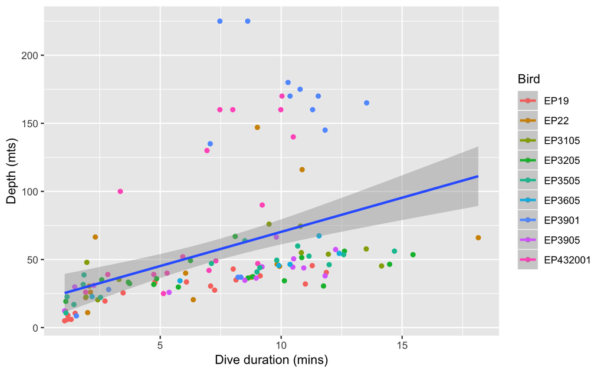

```r
peng_plot = ggplot(peng, aes(y=Depth, x=Duration, colour = Bird)) +
  geom_point() +
  geom_smooth(aes(group = 1), method = lm) +
  labs(y='Depth (mts)', x='Dive duration (mins)')

peng_plot
```

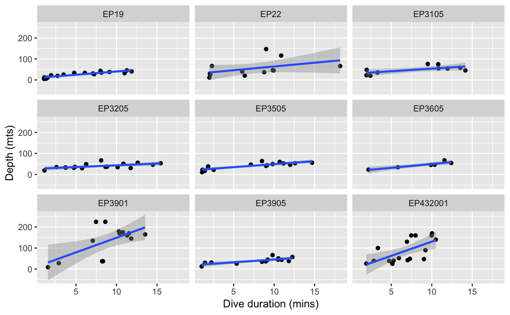

```r
peng_plot = ggplot(peng, aes(y=Depth, x=Duration)) +
  geom_point() +
  geom_smooth(method = lm) +
  facet_wrap(vars(Bird)) +
  labs(y='Depth (mts)',
       x='Dive duration (mins)')

peng_plot
```

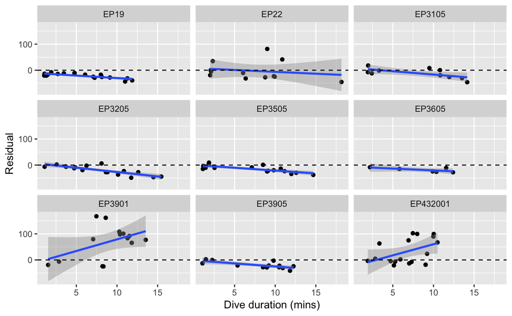

```r
#Checking the residuals to see better the relationship
model1 = lm(Depth ~ Duration, peng)
peng$Residual = residuals(model1)

residual_plot = peng_plot +
  aes(y=Residual) +
  geom_hline(yintercept=0, lty='dashed')

residual_plot %+% peng
```

```r
#trying with some polynomial analysis, including an additional predictor that catches some curved function of our basic predict. We will try squaring the dive duration (model degree 2, including "two durations")

model2 = lm(Depth ~ Duration + I(Duration^2), peng)

summary(model2)
```

```
Call:
lm(formula = Depth ~ Duration + I(Duration^2), data = peng)

Residuals:
    Min      1Q  Median      3Q     Max
-46.428 -27.508 -11.626   4.894 157.594

Coefficients:
              Estimate Std. Error t value Pr(>|t|)
(Intercept)    -1.7506    11.3234  -0.155  0.87739
Duration       13.7261     3.4014   4.035 9.55e-05 ***
I(Duration^2)  -0.5979     0.2246  -2.662  0.00881 **
---
Signif. codes:  0 ‘***’ 0.001 ‘**’ 0.01 ‘*’ 0.05 ‘.’ 0.1 ‘ ’ 1

Residual standard error: 42.29 on 122 degrees of freedom
Multiple R-squared:  0.2281,    Adjusted R-squared:  0.2155
F-statistic: 18.03 on 2 and 122 DF,  p-value: 1.38e-07
```

```r
#trying with polynomial functions in higher degrees

model3 = lm(Depth ~ poly(Duration, degree=3), peng)

summary(model3)
```

```
Call:
lm(formula = Depth ~ poly(Duration, degree = 3), data = peng)

Residuals:
    Min      1Q  Median      3Q     Max
-47.489 -26.503 -11.011   5.032 158.389

Coefficients:
                            Estimate Std. Error t value Pr(>|t|)
(Intercept)                   56.799      3.797  14.959  < 2e-16 ***
poly(Duration, degree = 3)1  227.647     42.452   5.362    4e-07 ***
poly(Duration, degree = 3)2 -112.598     42.452  -2.652  0.00906 **
poly(Duration, degree = 3)3  -12.834     42.452  -0.302  0.76292
---
Signif. codes:  0 ‘***’ 0.001 ‘**’ 0.01 ‘*’ 0.05 ‘.’ 0.1 ‘ ’ 1

Residual standard error: 42.45 on 121 degrees of freedom
Multiple R-squared:  0.2287,    Adjusted R-squared:  0.2096
F-statistic: 11.96 on 3 and 121 DF,  p-value: 6.507e-07
```

```r
model3b = lm(Depth ~ Duration + I(Duration^2) + I(Duration^3), peng)

summary(model3b)
```

```
Call:
lm(formula = Depth ~ Duration + I(Duration^2) + I(Duration^3),
    data = peng)

Residuals:
    Min      1Q  Median      3Q     Max
-47.489 -26.503 -11.011   5.032 158.389

Coefficients:
              Estimate Std. Error t value Pr(>|t|)
(Intercept)    2.21561   17.35763   0.128    0.899
Duration      11.14853    9.18388   1.214    0.227
I(Duration^2) -0.23085    1.23470  -0.187    0.852
I(Duration^3) -0.01436    0.04749  -0.302    0.763

Residual standard error: 42.45 on 121 degrees of freedom
Multiple R-squared:  0.2287,    Adjusted R-squared:  0.2096
F-statistic: 11.96 on 3 and 121 DF,  p-value: 6.507e-07
```

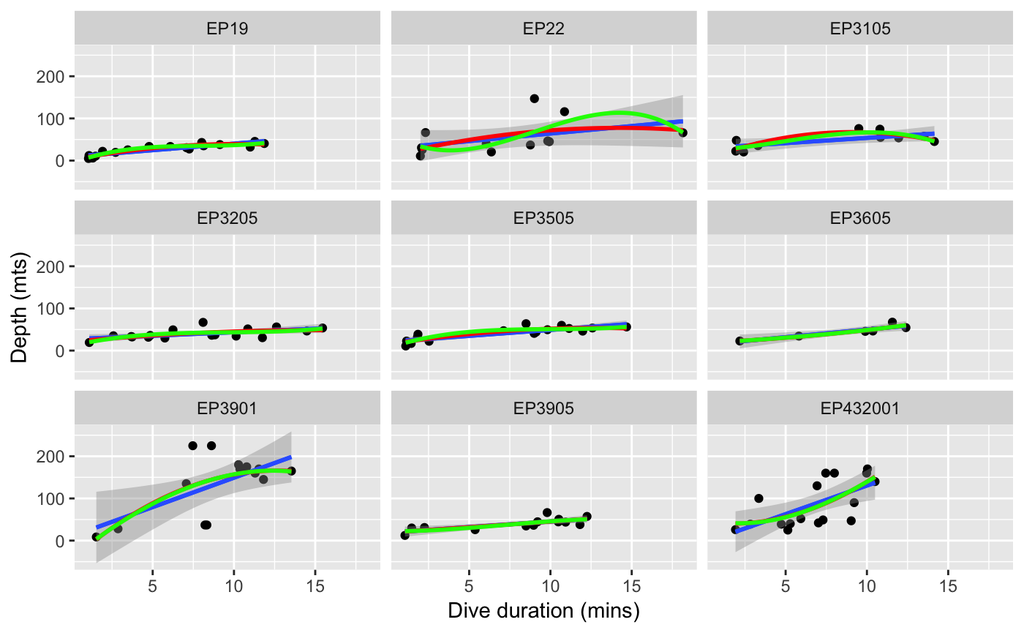

```r
peng_plot_models = peng_plot +
  geom_smooth(aes(group = 1), method=lm, se = FALSE) +
  geom_smooth(aes(group = 1), method=lm, formula = y ~ poly(x, degree=2), se=FALSE, color='red') +
  geom_smooth(aes(group = 1), method=lm, formula = y ~ poly(x, degree=3), se=FALSE, color='green')

peng_plot_models
```

```r
# Linear Mixed Effects using Hierarchical structure

# We are interested in estimating the linear relationship btw dive depth and dive duration among the different types of peguins (assuming that the types of birds could be a hierarchical structure)
table(peng$Bird)
```

```
    EP19     EP22   EP3105   EP3205   EP3505   EP3605   EP3901   EP3905 EP432001
      20       12       10       17       16        6       14       13       17
```

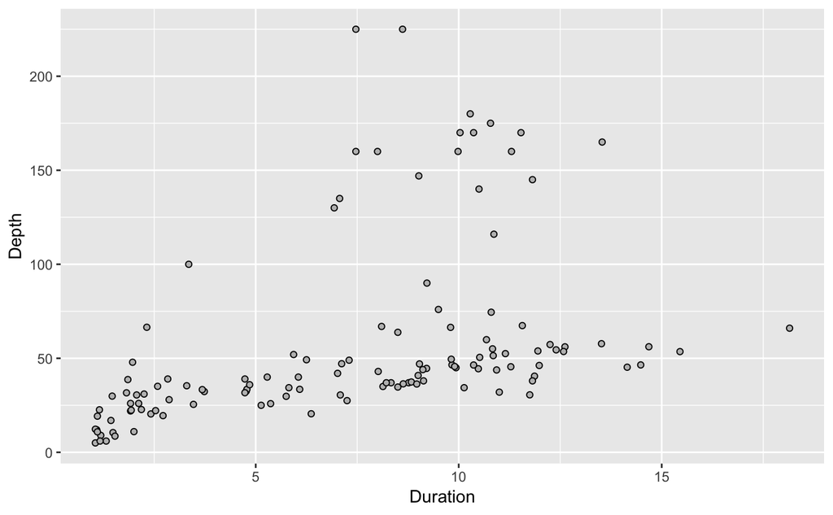

```r
# Plotting the data with jitter points to improve the visualization of the multiple points being plotted

fig1 = ggplot(peng, aes(y=Depth, x=Duration)) +
  geom_point(shape='circle filled', fill='grey',
             position=position_jitter())

fig1
```

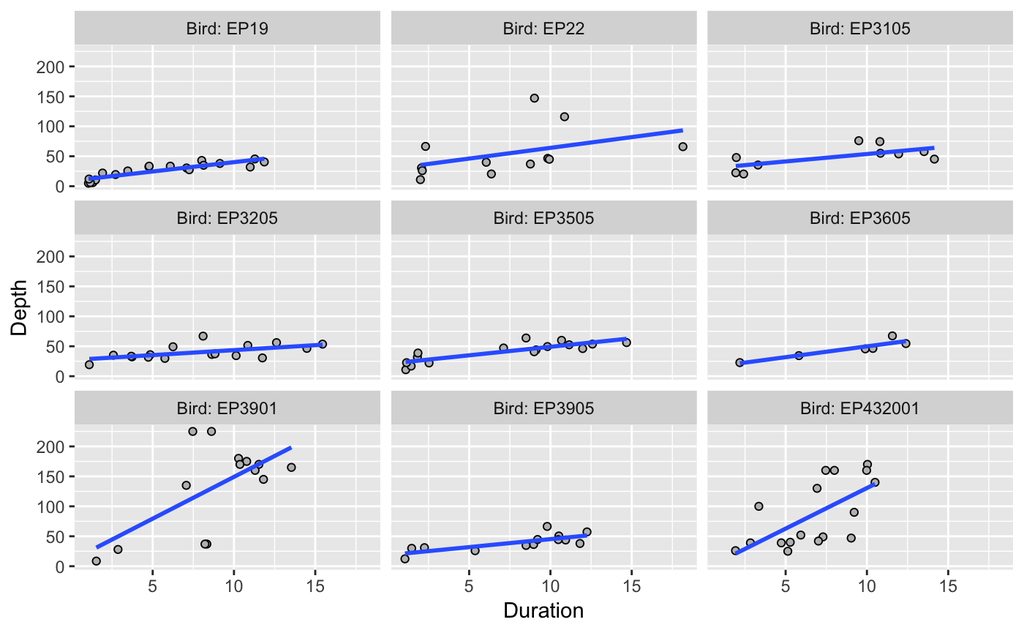

```r
fig2 <- fig1 +
  facet_wrap(~ Bird,
             labeller=label_both)

fig2 +
  geom_smooth(method=lm, se=FALSE)
```

1. First way of estimate the linear model using such data, ignoring the hierarchical structure: Lumping

```r
lump_model = lm(Depth ~ Duration, peng)

print(lump_model)
```

```
Call:
lm(formula = Depth ~ Duration, data = peng)

Coefficients:
(Intercept)     Duration
     20.117        5.017
```

```r
summary(lump_model)
```

```
Call:
lm(formula = Depth ~ Duration, data = peng)

Residuals:
    Min      1Q  Median      3Q     Max
-48.510 -24.928 -13.321   0.207 167.421

Coefficients:
            Estimate Std. Error t value Pr(>|t|)
(Intercept)  20.1167     7.9852   2.519    0.013 *
Duration      5.0173     0.9549   5.254 6.34e-07 ***
---
Signif. codes:  0 ‘***’ 0.001 ‘**’ 0.01 ‘*’ 0.05 ‘.’ 0.1 ‘ ’ 1

Residual standard error: 43.33 on 123 degrees of freedom
Multiple R-squared:  0.1833,    Adjusted R-squared:  0.1767
F-statistic: 27.61 on 1 and 123 DF,  p-value: 6.341e-07
```

Given that both groups share a common trend (dive behavior) but differ from one another a lot on average, then lumping is not very appropiate for our analysis.

2. Ignoring hierarchical structure using parameter averaging: estimating our model completely separate for each group: estimates for each group without generalization to the others #hay algo que no me resulta en el average model

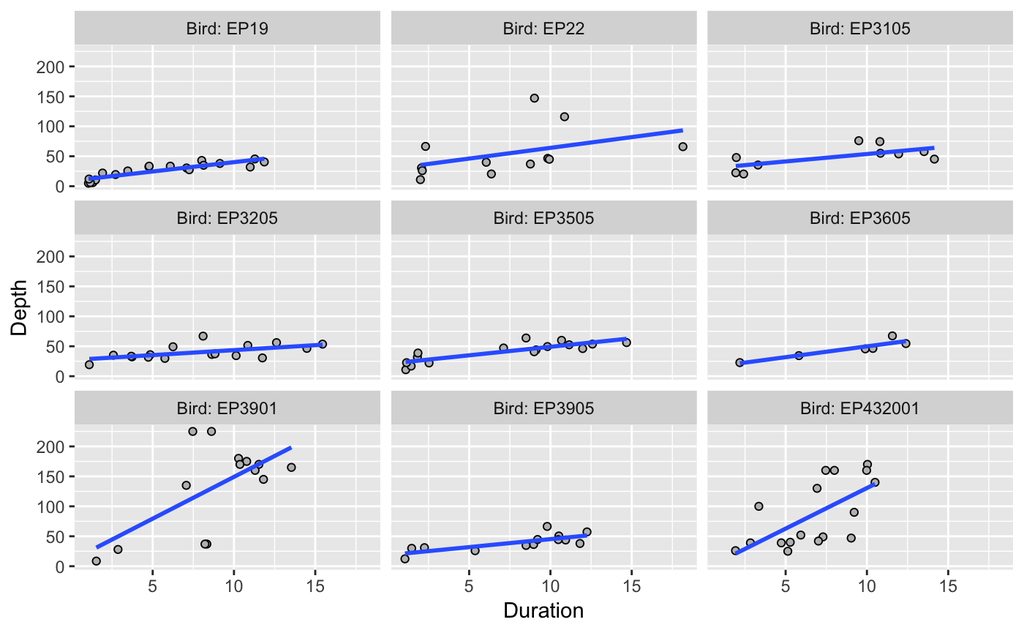

```r
fig2 + geom_smooth(method=lm, se=FALSE)
```

3. Mixed effects: to acknowledge the influence within every group (types of penguin birds) and the overall trend that all groups have in common estimation directly using the scaling. Still we get the singular fit warning

```r
library(lme4)
model_lme = lmer(Depth ~ scale(Duration) + (scale(Duration)|Bird), peng)
```

```
singular fit
```

```r
summary(model_lme)
```

```
Linear mixed model fit by REML ['lmerMod']
Formula: Depth ~ scale(Duration) + (scale(Duration) | Bird)
   Data: peng

REML criterion at convergence: 1206

Scaled residuals:
    Min      1Q  Median      3Q     Max
-3.0071 -0.3571 -0.1163  0.1985  4.0200

Random effects:
 Groups   Name            Variance Std.Dev. Corr
 Bird     (Intercept)     754.4    27.47
          scale(Duration) 327.4    18.09    1.00
 Residual                 810.6    28.47
Number of obs: 125, groups:  Bird, 9

Fixed effects:
                Estimate Std. Error t value
(Intercept)       54.642      9.519   5.741
scale(Duration)   21.312      6.581   3.238

Correlation of Fixed Effects:
            (Intr)
scale(Drtn) 0.884
convergence code: 0
singular fit
```

Eventhough there is a strong positive correlaton btw the random intercepts and random slopes, we are going to simplify the model in order to make it possible to estimate –> estimation of uncorrelated random effects

```r
model_uncorrelated = lmer(Depth ~ scale(Duration) + (scale(Duration)||Bird), peng)

summary(model_uncorrelated)
```

```
Linear mixed model fit by REML ['lmerMod']
Formula: Depth ~ scale(Duration) + ((1 | Bird) + (0 + scale(Duration) |      Bird))
   Data: peng

REML criterion at convergence: 1221.6

Scaled residuals:
    Min      1Q  Median      3Q     Max
-2.9287 -0.3208 -0.1014  0.2374  3.8802

Random effects:
 Groups   Name            Variance Std.Dev.
 Bird     (Intercept)     761.0    27.59
 Bird.1   scale(Duration) 288.1    16.97
 Residual                 850.5    29.16
Number of obs: 125, groups:  Bird, 9

Fixed effects:
                Estimate Std. Error t value
(Intercept)       55.541      9.622   5.772
scale(Duration)   20.674      6.372   3.245

Correlation of Fixed Effects:
            (Intr)
scale(Drtn) -0.012
```

We see thet there is not much difference to the fit of the model or to the estimates of the fixed effects.

# Visualization

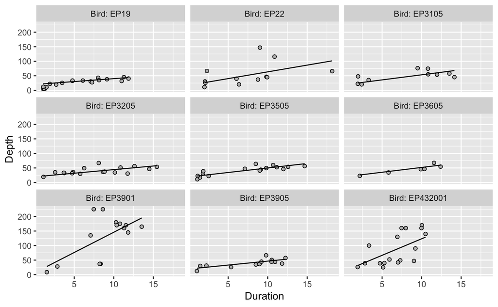

```r
peng$Predicted = predict(model_lme)

fig2 = fig2 %+% peng

fig3 = fig2 +
  geom_line(aes(y=Predicted))

fig3
```

shrinkage to see the diff btw the mixed effects mode and separate model for each group

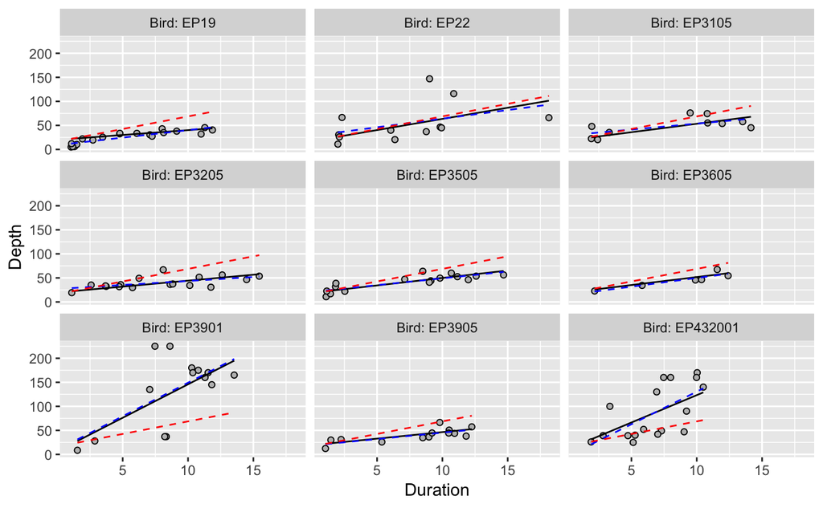

```r
model_separate = lm(Depth ~ Duration * Bird, peng)

peng$Predicted_fixed = predict(model_lme, re.form=~0)
peng$Predicted_separate = predict(model_separate)

fig4 = fig2 %+% peng +
  geom_line(aes(y=Predicted)) +
  geom_line(aes(y=Predicted_separate), color='blue', lty='dashed') +
  geom_line(aes(y=Predicted_fixed), color='red', lty='dashed')

fig4
```

R: as it can be seen, the differences btw the mixed effects model and the non-hierarchical model are clearest for the EP3901 and EP432001

R: For the first attempt of exercises (Linear vs polynomials), according to the parameters observed, the polynomial analysis in model degree 2 offers a better adjusted r-squared (in comparison with the linear one and the polynomials analysis in higher degrees).

Regarding the second part using LME and hierarchical methods, the mixed methods could be an appropiate option, once it is compared by shrinkage with the non-hierarchical models.